# Chronic inflammation project: GenePlexus expansion, prediction threshold = 0.80

Stephanie Hickey

12/31/2021

## Figure 1: expansion and clustering

### Figure 1a:Prediction and clustering schematic

Made in Google Slides

### For labeling trait types for the rest of Figure 1

I added the TraitType column to diseases_used_in_study.csv by hand to show whether the disease was categorized as a complex or autoimmune disease in the second column.

```r
# get complex vs ai labels
c_v_ai = read.csv("./data/diseases_used_in_study.csv", row.names = 1)

ai =
  c_v_ai %>%
  filter(TraitType == "Autoimmune Disease") %>%
  pull(Disease)

complex =
  c_v_ai %>%
  filter(TraitType == "Complex Disease") %>%
  pull(Disease)
```

**load data for figure1 -- gene cluster assignments**

Load the gene cluster assignment files for the real traits. These files are the output of filterAndClusterGeneplexusPredictions.R. We clustered all traits with an average GenePlexus three-fold CV log_{2}(auPRC/prior) >= 1.

```r
files = list.files("/mnt/scratch/hickeys6/chronic_inflammation/GenePlexus_SLA_string/clusters_threshold.80",
                   pattern = "--0.8--",
                   full.names = T)

clust_list = mclapply(files,
                   read.csv,
                   row.names = 1,
                   mc.cores = detectCores()-1)

clust_df = do.call(rbind, clust_list)

# add trait type to the cluster df
clust_df =
  clust_df %>%
  mutate(TraitType =
           case_when(Disease %in% ai ~ "Autoimmune Disease",
                     Disease %in% complex ~ "Complex Disease",
                     !Disease %in% c(ai, complex)  ~ "Non-disease Trait"))
```

In order to score the overlap of each cluster with chronic inflammation genes, we made 5k random gene sets for each disease or trait, each with the same number of degree-matched genes as its associated disease. For some traits, not all 5k of the random gene sets were able to be clustered. We consistently got errors with the leidenbase function for these traits. To keep things fair, we only analyzed overlaps between disease clusters and chronic inflammation genes for which all 5k of the random gene sets matched to that disease properly clustered. The output files from submit_clusterRandomGenes.R report the number of random gene sets that clustered properly. We used the following bash code to collate the number of clustered random gene sets per disease.

```bash
#bash script
cd ./run/sbatches_clusterRandomGenes
grep -hnr --with-filename "number clustered" *.out > number_clustered.txt
```

Then we used R to remove diseases/traits for which fewer than 5k fake traits clustered.

```r
nclust = read.delim("./run/sbatches_clusterRandomGenes/number_clustered.txt", header = F, sep = " ")

nclust$nFakesClustered = gsub("number clustered = ", "", nclust$V2)
nclust$nFakesClustered = as.numeric(nclust$nFakesClustered)

nclust$Disease = gsub("_BioGrid.*", "", nclust$V1)

remove_less5k =
  nclust %>%
  filter(nFakesClustered < 5000) %>%
  pull(Disease)

length(remove)
```

```
## [1] 1
```

We also removed the clustered chronic inflammation genes since we use all of the genes and not the clusters, Height_gene_shot, and Colitis it's not an autoimmune disease or complex disease, really, in retrospect. It's just a general term for inflammation of the bowl.

```r
remove_traits = c(remove,
                  "chronic_inflammation_gene_shot",
                  "chronic_inflammation_gene_shot_pubs_greater10",
                  "chronic_inflammation_go",
                  "Colitis",
                  "Height_gene_shot")
clust_df =
  clust_df %>%
  filter(!Disease %in% remove_traits)
```

### Figure 1b: Number of disease genes (seeds + predicted)

```r
# plot median n genes per trait type

clust_df$TraitType = factor(clust_df$TraitType,
                       levels = c("Autoimmune Disease",
                                  "Complex Disease",
                                  "Non-disease Trait"))

nGenes =
  clust_df %>%
  group_by(TraitType,
           Disease) %>%
  tally()

colnames(nGenes) =
  gsub("^n",
       "nGenes",
       colnames(nGenes))

Fig1b =
 nGenes %>%
  ggplot(aes(x = TraitType,
             y = nGenes)) +
  geom_jitter(shape=16,
              colour = "#90A4AE",
              position=position_jitter(0.2)) +
  geom_boxplot(color = c("#C62828"),
               fill = "NA",
               outlier.size=0,
               outlier.shape=NA) +
  theme_classic() +
  #theme(axis.text.x = element_text(angle = 45,
                                  # hjust=1)) +
  #xlab("Trait Type") +
  theme(axis.title.x=element_blank(),
        axis.text.x=element_blank()) +
  ylab("Number of genes") +
  ggtitle('B.')
```

### Figure 1c: Fraction predicted genes

```r
#find n predicted genes

nPredicted =
  clust_df %>%
  filter(GeneType == "predicted") %>%
  group_by(TraitType,
           Disease) %>%
  tally()

colnames(nPredicted) =
  gsub("^n",
       "nPredictedGenes",
       colnames(nPredicted))

nGenes = left_join(nGenes, nPredicted)
nGenes$propPredicted = nGenes$nPredictedGenes/nGenes$nGenes

Fig1c =
  nGenes %>%
  ggplot(aes(x = TraitType,
             y = propPredicted)) +
  geom_jitter(shape=16,
              colour = "#90A4AE",
              position=position_jitter(0.2)) +
  geom_boxplot(color = c("#C62828"),
               fill = "NA",
               outlier.size=0,
               outlier.shape=NA) +
  theme_classic() +
  theme(axis.text.x = element_text(angle = 45,
                                   hjust=1)) +
  theme(axis.title.x=element_blank()) +
  ylab("Proportion predicted genes") +
  ggtitle('C.')
```

### Figure 1d: Number of clusters containing >=5 genes

```r
nGenesPerCluster =
  clust_df %>%
  group_by(Disease,
           Cluster,
           TraitType) %>%
  tally()

nClusters5 =
  nGenesPerCluster %>%
  filter(n >= 5) %>%
  group_by(Disease,
           TraitType) %>%
  tally()

colnames(nClusters5) =
  gsub("^n",
       "nClusterSize5",
       colnames(nClusters5))

Fig1d =
  nClusters5 %>%
  ggplot(aes(x = TraitType,
             y = nClusterSize5)) +
  geom_jitter(shape=16,
              colour = "#90A4AE",
              position=position_jitter(0.2)) +
  geom_boxplot(color = c("#C62828"),
               fill = "NA",
               outlier.size=0,
               outlier.shape=NA) +
  theme_classic() +
  theme(axis.text.x = element_text(angle = 45,
                                   hjust=1)) +
  theme(axis.title.x=element_blank()) +
  ylab("Clusters size >= 5") +
  ggtitle('D.')
```

### Figure 1e: Fraction of genes in clusters containing >=5 genes

```r
clusters5 =
  nGenesPerCluster %>%
  filter(n >= 5) %>%
  pull(Cluster)

nGenes5 =
  clust_df %>%
  select(Disease,
         Cluster,
         TraitType) %>%
  filter(Cluster %in% clusters5) %>%
  group_by(Disease,
           TraitType) %>%
  tally()

colnames(nGenes5) =
  gsub("^n",
       "nGenesInClusterSize5",
       colnames(nGenes5))

nGenes  = left_join(nGenes, nGenes5)
nGenes$nGenesInClusterSize5[is.na(nGenes$nGenesInClusterSize5)] = 0
nGenes$propClustered = nGenes$nGenesInClusterSize5/nGenes$nGenes

Fig1e =
  nGenes %>%
  ggplot(aes(x = TraitType,
             y = propClustered)) +
  geom_jitter(shape=16,
              colour = "#90A4AE",
              position=position_jitter(0.2)) +
  geom_boxplot(color = c("#C62828"),
               fill = "NA",
               outlier.size=0,
               outlier.shape=NA) +
  theme_classic() +
  theme(axis.text.x = element_text(angle = 45,
                                   hjust=1)) +
  theme(axis.title.x=element_blank()) +
  ylab("Proportion clustered genes") +
  ggtitle('E.')
```

### Figure 1f: Fraction of GOBP enriched clusters

These files are the output of find_GOBP_enriched_clusters_GenePlexus.R

```r
# prep gobp enrichment df
go_path = "/mnt/scratch/hickeys6/chronic_inflammation/GenePlexus_SLA_string/GOBP_enrichment"

go_files = list.files(go_path,
                      full.names = T,
                      pattern = "--0.8--")

go_list = mclapply(go_files,
                   read.csv,
                   row.names = 1,
                   mc.cores= detectCores()-1)

godf = do.call(rbind, go_list)

# add label to gobp file
godf =
  godf %>%
  mutate(TraitType =
           case_when(Disease %in% ai ~ "Autoimmune Disease",
                     Disease %in% complex ~ "Complex Disease",
                     !Disease %in% c(ai, complex)  ~ "Non-disease Trait"))

remove_traits = c(remove,
                  "chronic_inflammation_gene_shot",
                  "chronic_inflammation_gene_shot_pubs_greater10",
                  "chronic_inflammation_go",
                  "Colitis")
godf =
  godf %>%
  filter(!Disease %in% remove_traits,
         Cluster %in% clusters5)

# how many clusters have at least one sig overlap?
n_sig =
  godf %>%
  filter(FDR < .05) %>%
  group_by(Cluster,
           Disease,
           TraitType) %>%
  tally() %>%
  arrange(n)

# per disease
n_sig_per_disease =
  n_sig %>%
  group_by(Disease,
           TraitType) %>%
  tally()

colnames(n_sig_per_disease) =
  gsub("^n",
       "nGOBP_enriched",
       colnames(n_sig_per_disease))

nClusters5 = left_join(nClusters5, n_sig_per_disease)
nClusters5$nGOBP_enriched[is.na(nClusters5$nGOBP_enriched)] = 0
nClusters5$propGOBP_enriched = nClusters5$nGOBP_enriched/nClusters5$nClusterSize5

Fig1f =
  nClusters5 %>%
  ggplot(aes(x = TraitType,
             y = propGOBP_enriched)) +
  geom_jitter(shape=16,
              colour = "#90A4AE",
              position=position_jitter(0.2)) +
  geom_boxplot(color = c("#C62828"),
               fill = "NA",
               outlier.size=0,
               outlier.shape=NA) +
  theme_classic() +
  theme(axis.text.x = element_text(angle = 45,
                                   hjust=1)) +
  theme(axis.title.x=element_blank()) +
  ylab("Proportion GOBP enriched") +
  ggtitle('F.')
```

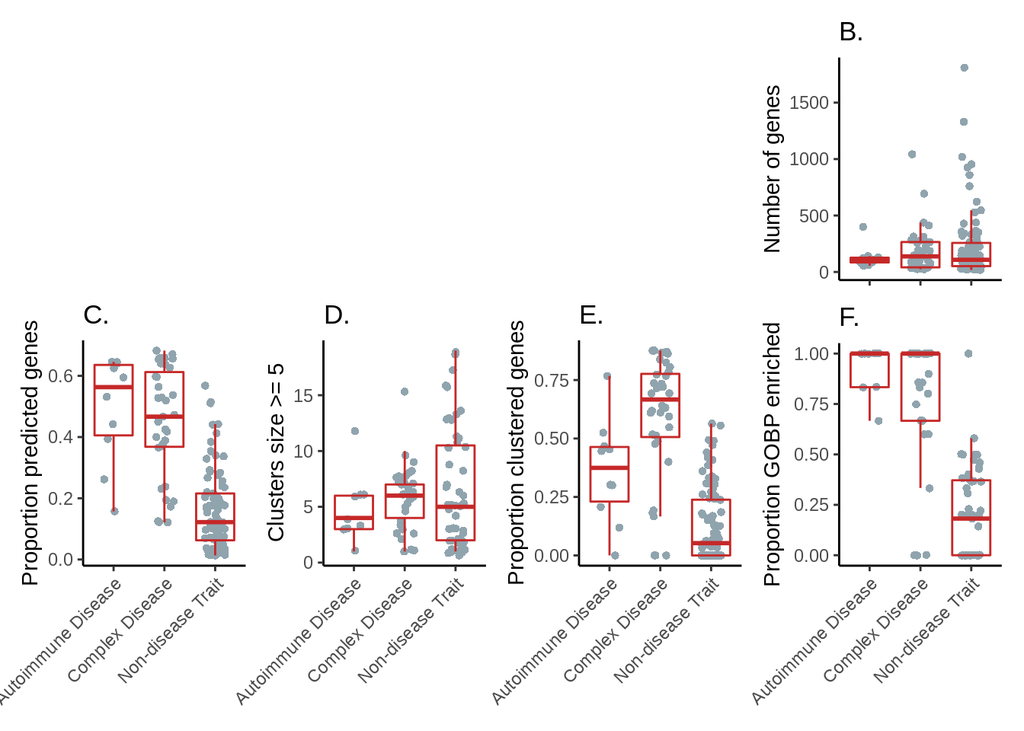

```r
fig1 =
  (plot_spacer() / Fig1c) |
  (plot_spacer() / Fig1d) |
  (plot_spacer() / Fig1e) |
  (Fig1b / Fig1f)

ggsave(file = paste0(figure_path, "/Figure1.png"),
       width = 7, height = 5, dpi = 300)
fig1
```

## Figure 2: Chronic infammation cluster overlaps

### Figure 2a: Number of traits overlapping at least one chronic inflammation cluster

These data are the output of calculatePermutedFDR_faketraits.R

```r
# load the overlap results file = res_df
res_df = loadRData("./results/GenePlexus_String_Adjacency/overlap_results_real_only.Rdata")

# add TraitType to res_df
res_df =
  res_df %>%
  mutate(TraitType =
           case_when(Disease %in% ai ~ "Autoimmune Disease",
                     Disease %in% complex ~ "Complex Disease",
                     !Disease %in% c(ai, complex)  ~ "Non-disease Trait"))

res_df =
  res_df %>%
  filter(!Disease %in% remove_traits)


# filter for significant overlaps
cutoff = 0.01
sig = res_df %>%
  filter(PermutedFDR < cutoff)

# diseases with at least one cluster
# significantly overlapping a CI cluster
sig_disease =
  sig %>%
  ungroup() %>%
  select(Disease,
         TraitType) %>%
  distinct() %>%
  mutate(Signficant_Overlap = TRUE)

#make not-significant df
#filter for keep_disease
not_sig_diseases =
  res_df %>%
  ungroup() %>%
  filter(!Disease %in% sig_disease$Disease) %>%
  select(Disease,
         TraitType) %>%
  distinct() %>%
  mutate(Signficant_Overlap = FALSE)

# bind
sig_disease = rbind(sig_disease,
                    not_sig_diseases)

# tally sig and not sig by trait type
tally_sig_disease =
  sig_disease %>%
  group_by(TraitType,
           Signficant_Overlap) %>%
  tally()

# plot
tally_sig_disease$TraitType = factor(tally_sig_disease$TraitType,
                                   levels = c("Autoimmune Disease",
                                              "Complex Disease",
                                              "Non-disease Trait"))

Fig2a = ggplot(tally_sig_disease,
       aes(x = TraitType,
           y = n,
           fill = Signficant_Overlap)) +
  geom_bar(stat="identity") +
  geom_text(aes(label = n),
            position = position_stack(vjust = 0.5)) +
  theme_classic() +
  scale_fill_manual(values=c("#90a4ae",
                             "#C62828")) +
  xlab("Trait type") +
  ylab("n Traits") +
  guides(fill = guide_legend("CI Overlap")) +
  ggtitle('A.') +
  coord_flip()
```

### Figure 2b: Overlap barplot: autoimmune

```r
sig =
  sig %>%
  ungroup() %>%
  mutate(PlotText = paste0(nSharedGenes, "/", nGroup2),
         Log10FDR = -log10(PermutedFDR))

sig$Group2 = gsub("_", " ", sig$Group2)
sig$Group2 = gsub("Crohn", "Crohn's", sig$Group2)

plot_order =
  sig %>%
  filter(TraitType == "Autoimmune Disease") %>%
  arrange(Disease, desc(Log10FDR)) %>%
  pull(Group2)

sig_ai =
  sig %>%
  filter(TraitType == "Autoimmune Disease")

sig_ai$Group2 = factor(sig_ai$Group2,
                       levels = plot_order)

Fig2b =
  ggplot(sig_ai,
       aes(x = Group2,
           y = Log10FDR)) +
  geom_col(fill = "#C62828") +
  geom_text(aes(label = PlotText),
            position = position_stack(vjust = 0.5)) +
  theme_classic() +
  xlab("Cluster") +
  ylab(expression("-log"[10]*"(FDR)")) +
  ggtitle('B.') +
  coord_flip()
```

### Figure 2c: Overlap barplot: complex disease

```r
plot_order =
  sig %>%
  filter(TraitType == "Complex Disease") %>%
  arrange(Disease, desc(Log10FDR)) %>%
  pull(Group2)

sig_cd =
  sig %>%
  filter(TraitType == "Complex Disease")

sig_cd$Group2 = factor(sig_cd$Group2,
                       levels = plot_order)

Fig2c =
  ggplot(sig_cd,
       aes(x = Group2,
           y = Log10FDR)) +
  geom_col(fill = "#C62828") +
  geom_text(aes(label = PlotText),
            position = position_stack(vjust = 0.5)) +
  theme_classic() +
  xlab("Cluster") +
  ylab(expression("-log"[10]*"(FDR)")) +
  ggtitle('C.') +
  coord_flip()
```

### Fig2: composite a-c

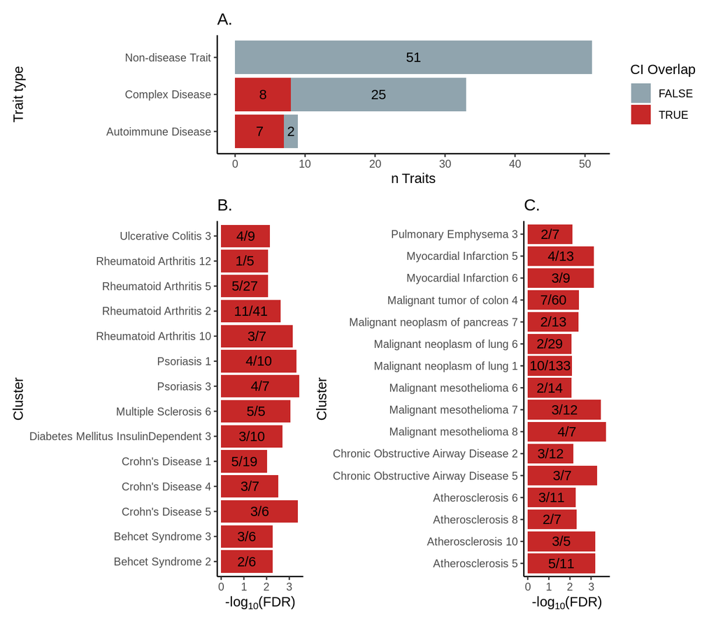

```r
fig2 = Fig2a / (Fig2b + Fig2c) +  plot_layout(heights = c(1,3))

ggsave(file = paste0(figure_path, "/Figure2.png"),
       width = 8, height = 5, dpi = 300)
fig2
```

## Figure 3: Drug results overivew

### Figure 3a: Drug Scoring schematic

Made in Google Slides

### Figure 3b: Number of significant drugs per disease previously indicated vs not -- Autoimmune

These results are the output of Alex's Drug Code

```r
drugs = read.delim("./results/GenePlexus_String_Adjacency/GenePlexus_Drugs.tsv")

drugs =
  drugs %>%
  mutate(TraitType =
           case_when(Disease %in% ai ~ "Autoimmune Disease",
                     Disease %in% complex ~ "Complex Disease",
                     !Disease %in% c(ai, complex)  ~ "Non-disease Trait"))

# remove colitis, it's not an autoimmune disease or complex disease, really
drugs =
  drugs %>%
  filter(!Disease == "Colitis")

# Calculate proportion of significant drug-disease pairs
# set FDR threshold
cutoff = .05

# tally all drug-disease pairs we found for ai's and complex disease
tally_drugs =
  drugs %>%
  filter(FDR <= cutoff) %>%
  group_by(TraitType) %>%
  tally
colnames(tally_drugs)[2] = "nDrugs"

# tally all drug-disease pairs we found for each disease
tally_drugs_disease =
  drugs %>%
  filter(FDR <= cutoff) %>%
  group_by(TraitType,
           Disease) %>%
  tally
colnames(tally_drugs_disease)[3] = "nDrugs"

# filter for significant drug disease pairs
sig_drugs =
  drugs %>%
  filter(FDR < cutoff) %>%
  arrange(FDR)

# load IDs for our diseases
all_disease = read.csv("./data/chronic_inflammation_diseases_with_DOID.csv", row.names = 1)

# get rid of DOID and names
all_disease =
  all_disease %>%
  select(diseaseId,
         diseaseName) %>%
  distinct()

#change disease names to match ours
all_disease$diseaseName = gsub(" ", "_", all_disease$diseaseName)
all_disease$diseaseName = gsub("([_])|[[:punct:]]", "\\1", all_disease$diseaseName)

# filter for diseases with significant results
# get rid of colitis
disease_sig  =
  all_disease %>%
  filter(diseaseName %in% unique(sig_drugs$Disease),
         !diseaseName == "Colitis")

colnames(disease_sig) = c("umls_cui", "Disease")

# load drug central data from Alex
indications = read.delim("./drugs/data/drugcentral/indications.tsv")
# ids for drugs filtered through expert curation
struct_ids = read.delim("./drugs/data/drugcentral/structid_drugnames.tsv")

# filter indications by curated struct_ids
# and add the drug_names
indications = merge(indications,
                    struct_ids,
                    by = "struct_id")

# filter for indication or off-label use
# filter for diseases and syndromes T047 and Neoplastic process T191
# https://www.ncbi.nlm.nih.gov/pmc/articles/PMC4450611/
indications = indications %>%
  filter(relationship_name %in% c("indication","off-label use"),
         cui_semantic_type %in% c("T047", "T191"))

# select cols of interest from drug_sig
sig_drugs_oi =
  sig_drugs %>%
  select(Disease,
         pvals,
         FDR,
         STRUCT_ID,
         Drugs)

# add cuid for matching disease
sig_drugs_oi = left_join(sig_drugs_oi,
                         disease_sig,
                         by = "Disease")

indications_oi =
  indications %>%
  select(struct_id,
         umls_cui,
         relationship_name)

colnames(sig_drugs_oi) = gsub("STRUCT_ID",
                              "struct_id",
                              colnames(sig_drugs_oi))

sig_drugs_oi = left_join(sig_drugs_oi,
                         indications_oi,
                         by = c("umls_cui",
                               "struct_id"))

colnames(sig_drugs_oi) = gsub("relationship_name",
                              "Known_Relationship",
                               colnames(sig_drugs_oi))

sig_drugs_oi$Known_Relationship[is.na(sig_drugs_oi$Known_Relationship)] = "none"

sig_drugs_oi$Previously_indicated_umls_cui =
  ifelse(sig_drugs_oi$Known_Relationship == "indication" |
           sig_drugs_oi$Known_Relationship == "off-label use",
         TRUE,
         FALSE)

umls_match =
  sig_drugs_oi %>%
  filter(Previously_indicated_umls_cui == TRUE) %>%
  group_by(Disease) %>%
  tally()

colnames(umls_match) = gsub("^n",
                            "n previous drug associations",
                            colnames(umls_match))

tally_indication =
  sig_drugs_oi %>%
  group_by(Disease, Previously_indicated_umls_cui) %>%
  tally()

tally_indication =
  tally_indication %>%
  mutate(TraitType =
           case_when(Disease %in% ai ~ "Autoimmune Disease",
                     Disease %in% complex ~ "Complex Disease",
                     !Disease %in% c(ai, complex)  ~ "Non-disease Trait"))

tally_indication$Disease = gsub("_", " ", tally_indication$Disease)
tally_indication$Disease = gsub("Crohn", "Crohn's", tally_indication$Disease)

# arrange by n associated drugs
tally_drugs =
  sig_drugs_oi %>%
  group_by(Disease) %>%
  tally()

tally_drugs$Disease = gsub("_", " ", tally_drugs$Disease)
tally_drugs$Disease = gsub("Crohn", "Crohn's", tally_drugs$Disease)

tally_drugs =
  tally_drugs %>%
  mutate(TraitType =
           case_when(Disease %in% ai ~ "Autoimmune Disease",
                     Disease %in% complex ~ "Complex Disease",
                     !Disease %in% c(ai, complex)  ~ "Non-disease Trait"))

plot_levels =
  tally_drugs %>%
  arrange(n) %>%
  pull(Disease)

tally_indication$Disease =
  factor(tally_indication$Disease,
         levels = plot_levels)

# plot
Fig3b =
  tally_indication %>%
  filter(TraitType == "Autoimmune Disease") %>%
  ggplot(aes(x = Disease,
             y = n,
             fill = Previously_indicated_umls_cui)) +
  geom_bar(stat="identity") +
  geom_text(aes(label = n),
            position = position_stack(vjust = 0.5)) +
  theme_classic() +
  scale_fill_manual(values=c("#90a4ae",
                             "#C62828")) +
  theme(axis.title.x=element_blank(),
        axis.title.y=element_blank()) +
  guides(fill = guide_legend("Previously Indicated")) +
  ggtitle('B.') +
  coord_flip()
```

### Figure 3c: Number of significant drugs per disease previously indicated vs not -- Complex

```r
# plot
Fig3c =
  tally_indication %>%
  filter(TraitType == "Complex Disease") %>%
  ggplot(aes(x = Disease,
             y = n,
             fill = Previously_indicated_umls_cui)) +
  geom_bar(stat="identity") +
  geom_text(aes(label = n),
            position = position_stack(vjust = 0.5)) +
  theme_classic() +
  scale_fill_manual(values=c("#90a4ae",
                             "#C62828")) +
  theme(axis.title.y=element_blank()) +
  ylab("n Drugs") +
  guides(fill = guide_legend("Previously Indicated")) +
  ggtitle('C.') +
  coord_flip()
```

### Fig3: composite b-c

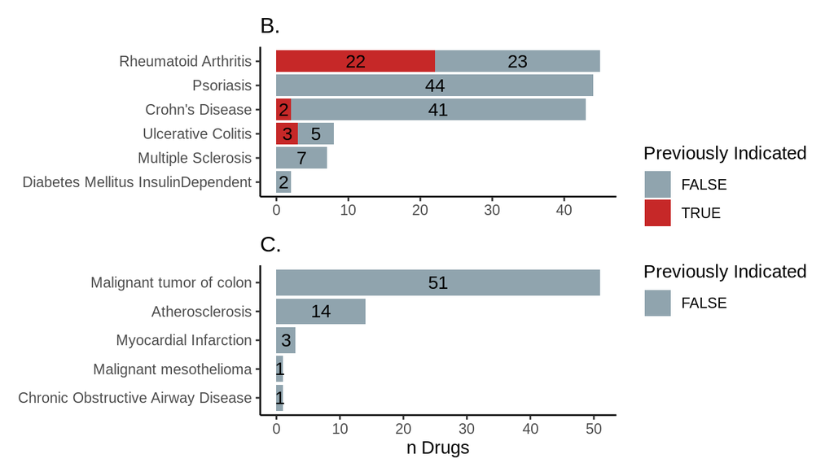

```r
fig3 = Fig3b / Fig3c +  plot_layout(guides = 'collect')

ggsave(file = paste0(figure_path, "/Figure3.png"),
       width = 6.5, height = 3.25, dpi = 300)
fig3
```

## Figure 4: Cytoscape of top drug-gene-disease associations by FDR

Edges and node metadata selection shown in drug_repurposing_analysis.Rmd

## Supplementary tables

#### Table S1: For traits considered in drug analysis:

- Disease
- CU ID (if applicable)
- Trait Type
- Average CV score
- n seed genes
- n predicted genes
- n clusters >= 5 genes

```r
# load the geneplexus summary df
# object is summary_df
load("/mnt/research/compbio/krishnanlab/projects/chronic_inflammation/results/GenePlexus_parameter_checks/Geneplexus_summary.Rdata")

remove_old_traits = c("Vasculitis",
                      "Sarcopenia",
                      "Irritable_Bowel_Syndrome",
                      "Chronic_Kidney_Diseases",
                      "Chronic_Periodontitis")
sla_summary =
  summary_df %>%
  filter(Network == "STRING",
         Features == "Adjacency",
         !Disease %in% remove_old_traits) %>%
  select(Disease,
         Network,
         Features,
         negativesFrom,
         nSeeds,
         nNewGenes,
         nNegs,
         CVscore) %>%
  mutate(TraitType =
           case_when(Disease %in% ai ~ "Autoimmune Disease",
                     Disease %in% complex ~ "Complex Disease",
                     !Disease %in% c(ai, complex) ~ "Non-disease Trait"))

# mark traits where we could cluster all 5k faketraits
# these are the only ones considered in the overlap analysis

nclust_remove =
  nclust %>%
  filter(nFakesClustered < 5000) %>%
  pull(Disease)

# remove colitis, it's not an autoimmune disease or complex disease, really
remove_traits = c("chronic_inflammation_gene_shot",
                  "chronic_inflammation_gene_shot_pubs_greater10",
                  "Colitis",
                  "Height_gene_shot")

sla_summary =
  sla_summary %>%
  filter(!Disease %in% remove_traits) %>%
  mutate(Did5KfakeTraitsCluster =
           case_when(!Disease %in% nclust_remove ~ TRUE,
                     Disease %in% nclust_remove ~ FALSE))

# we didn't use the cluster info for chronic_inflammation_go
sla_summary$Did5KfakeTraitsCluster[which(sla_summary$Disease == "chronic_inflammation_go")] = NA
sla_summary$TraitType[which(sla_summary$Disease == "chronic_inflammation_go")] = "Chronic inflammatory response"

colnames(sla_summary) = gsub("nNewGenes",
                             "nPredictedGenes",
                             colnames(sla_summary))

colnames(sla_summary) = gsub("CVscore",
                             "averageCVscore",
                             colnames(sla_summary))

# add n clusters >= 5 genes
files = list.files("/mnt/scratch/hickeys6/chronic_inflammation/GenePlexus_SLA_string/clusters_threshold.80",
                    pattern = "--0.8--",
                    full.names = T)

clust_list = mclapply(files,
                   read.csv,
                   row.names = 1,
                   mc.cores= detectCores()-1)

clust_df = do.call(rbind, clust_list)

gene_tally =
  clust_df %>%
  group_by(Cluster) %>%
  tally()

clusters5 =
  gene_tally %>%
  filter(n >= 5) %>%
  pull(Cluster)

clust5_tally =
  clust_df %>%
  ungroup() %>%
  filter(Cluster %in% clusters5) %>%
  group_by(Disease) %>%
  tally()

colnames(clust5_tally) = c("Disease", "nClustersAtLeast5Genes")

disease_no5_clust = unique(clust_df$Disease)[!unique(clust_df$Disease) %in% clust5_tally$Disease]

disease_no5_clust = data.frame(Disease = disease_no5_clust,
                               nClustersAtLeast5Genes = 0)

clust5_tally = rbind(clust5_tally, disease_no5_clust)

sla_summary = left_join(sla_summary, clust5_tally)

# add cuid when applicable
dg = read.delim("./data/disgenet_2020-10_curated_gene_disease_associations.tsv")

to_add =
  dg %>%
  select(diseaseName,
         diseaseId) %>%
  distinct()

to_add$diseaseName = gsub(" ", "_", to_add$diseaseName)
to_add$diseaseName = gsub("([_])|[[:punct:]]", "\\1", to_add$diseaseName)

colnames(to_add) = c("Disease", "UMLS_CUI")

sla_summary = left_join(sla_summary, to_add)

sla_summary =
  sla_summary %>%
  select(Disease,
         UMLS_CUI,
         everything())

write.table(sla_summary,
            file = paste0(figure_path, "/tableS1_trait_summary.tsv"),
            sep = "\t",
            quote = F,
            row.names = F)
```

#### Table S2: Gene Cluster Assignments for traits considered in drug analysis

- Disease
- CU ID
- Trait Type
- Entrez ID
- Gene Symbol
- Gene Type (seed vs predicted)
- Cluster (or NA for chronic inflammation genes)

```r
# add trait type to clust file
clust_df =
  clust_df %>%
  mutate(TraitType =
           case_when(Disease %in% ai ~ "Autoimmune Disease",
                     Disease %in% complex ~ "Complex Disease",
                     !Disease %in% c(ai, complex) ~ "Non-disease Trait"))

clust_df$TraitType[which(clust_df$Disease == "chronic_inflammation_go")] = "Chronic inflammatory response"
clust_df$Cluster[which(clust_df$Disease == "chronic_inflammation_go")] = NA

clust_df =
  clust_df %>%
  filter(!Disease %in% remove_traits)

# add gene symbol
sym = entrez2symbol(as.character(clust_df$Gene))
clust_df$GeneSymbol = sym
unloadNamespace("org.Hs.eg.db")

# add UMLS_CUI
clust_df = left_join(clust_df, to_add)

# select and arrange cols
clust_df =
  clust_df %>%
  select(Gene,
         GeneSymbol,
         GeneType,
         UMLS_CUI,
         Disease,
         TraitType,
         Cluster)

colnames(clust_df) =
  gsub("Gene$",
       "Entrez",
       colnames(clust_df))

write.table(clust_df,
            file = paste0(figure_path, "/tableS2_disease_genes_with_cluster_assignment.tsv"),
            sep = "\t",
            quote = F,
            row.names = F)
```

#### Table S3: Overlap Results

```r
ol_res = loadRData("/mnt/research/compbio/krishnanlab/projects/chronic_inflammation/results/GenePlexus_String_Adjacency/overlap_results_real_only.Rdata")

# remove hypergeometric results and ChronicInf cols
ol_res =
  ol_res %>%
  ungroup() %>%
  filter(!Disease == "Colitis") %>%
  select(-Pval,
         -FDR,
         -ChronicInf)

write.table(ol_res,
            file = paste0(figure_path, "/tableS3_cluster_overlaps_with_chronic_inflammation_genes.tsv"),
            sep = "\t",
            quote = F,
            row.names = F)
```

#### Table S4: Clinical trial hypergeometric results

```r
ct_res = read.csv("./results/GenePlexus_String_Adjacency/clinical_trial_hypergeometric_results.csv", row.names = 1)

write.table(ct_res,
            file = paste0(figure_path, "/tableS4_clinical_trial_hypergeometric_test_results.tsv"),
            sep = "\t",
            quote = F,
            row.names = F)
```

#### Table S5: All Drug Results

```r
drug_res = read.delim("./results/GenePlexus_String_Adjacency/GenePlexus_Drugs.tsv")

# add UMLS_CUI
drug_res = left_join(drug_res, to_add)

# reorder cols
drug_res =
  drug_res %>%
  select(Disease,
         UMLS_CUI,
         Drugs,
         STRUCT_ID,
         EntrezFound,
         SymbolFound,
         Clustersforgenes,
         Score,
         pvals,
         FDR,
         indications,
         relationship
         )

colnames(drug_res) = c("Disease",
                       "UMLS_CUI",
                       "Drug",
                       "STRUCT_ID",
                       "TargetEntrez",
                       "TargetSymbol",
                       "TargetCluster",
                       "Score",
                       "pval",
                       "FDR",
                       "indications",
                       "relationship")

write.table(ct_res,
            file = paste0(figure_path, "/tableS5_all_drug_disease_predictions.tsv"),
            sep = "\t",
            quote = F,
            row.names = F)
```